# Anomalías térmicas en Costa Rica — VIIRS

Detecciones del sensor VIIRS (VIIRS_SNPP_SP de NASA FIRMS) y área quemada (VNP64A1)

Autor/a

Organización Incendios Forestales

Fecha de publicación

17 de noviembre de 2026

## Introducción

Este reporte presenta las anomalías térmicas (detecciones de fuego activo) registradas por el sensor **VIIRS** a bordo del satélite Suomi-NPP en el territorio continental de **Costa Rica**. Es el análogo del reporte basado en MODIS, con la misma metodología y los mismos productos, pero con un instrumento distinto: los datos provienen del producto **VIIRS_SNPP_SP** (procesamiento estándar) del sistema [FIRMS](https://firms.modaps.eosdis.nasa.gov/) de la NASA y el área quemada del producto **VNP64A1**. Existen además reportes con el VIIRS de NOAA-20 (desde 2018) y de NOAA-21 (desde 2024), el mismo instrumento en otras plataformas.

El ámbito es **continental** (sin la Isla del Coco) y el límite nacional es la unión de las siete provincias de la cartografía oficial 1:5000 del IGN, servida por el [SNIT](https://www.snitcr.go.cr/); los detalles están en el reporte MODIS.

Las series se publican por separado y **no deben sumarse ni empalmarse**: VIIRS observa con un píxel de 375 m frente al de ~1 km de MODIS, de modo que detecta muchos más fuegos —y fuegos más pequeños— sobre el mismo territorio. Cualquier serie que uniera ambos sensores mostraría un salto artificial en 2012, cuando VIIRS entra en operación, que sería un cambio de instrumento y no un cambio en el régimen de fuego.

El interés de VIIRS es doble. Por un lado es la **continuidad** del registro: las misiones Terra y Aqua, que llevan MODIS, terminan en 2027. Por otro, su mayor resolución permite contrastar los hallazgos obtenidos con MODIS y distinguir cuáles son propiedades del fuego y cuáles artefactos del tamaño del píxel.

El período analizado va del **20/01/2012** al **30/10/2026**, con un total de **84 583** detecciones dentro del país. El límite nacional está delimitado a escala 1:5000, una precisión muy superior a la de los píxeles VIIRS (375 m en el nadir), así que el recorte no introduce error apreciable por la geometría del límite.

Como en los demás reportes, una **anomalía térmica no es necesariamente un incendio forestal**: a escala nacional el registro incluye quemas agrícolas y ocasionalmente fuentes industriales, además de los incendios de vegetación.

## Mapa animado

Detecciones mensuales de anomalías térmicas; el color indica la potencia radiativa del fuego (FRP).

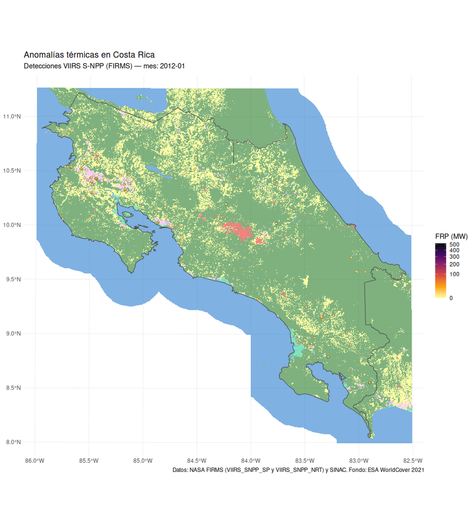

## Video resumen

Resumen mensual en formato de video: detecciones de fuego activo (VIIRS) con su estela de los meses recientes y píxeles de área quemada (VNP64A1), sobre el relieve del país teñido por la cobertura de la tierra (WorldCover 2021). Los contadores muestran el acumulado desde el inicio del registro y, debajo, el mes en curso con sus valores, cada serie por separado: son magnitudes complementarias y no sumables.

[video not shown]

El cartel estático resume las dos series mensuales del video: los acumulados arriba y, en paneles separados, las hectáreas quemadas y las detecciones por mes, con el mes máximo de cada serie rotulado.

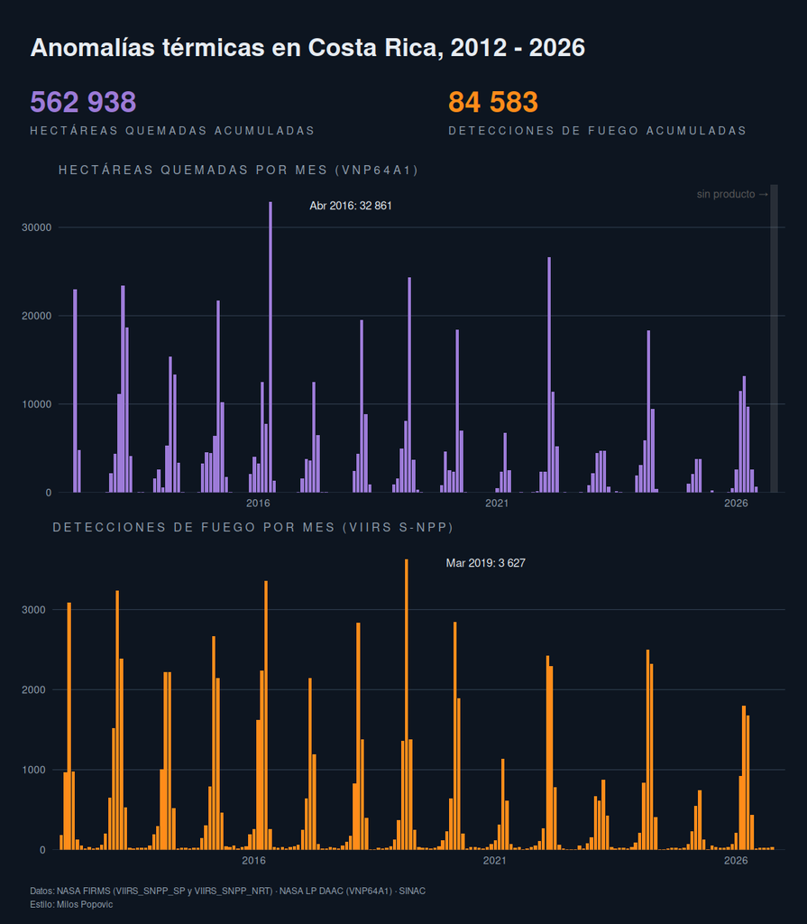

## Mapa interactivo

A escala nacional el registro completo suma demasiadas detecciones para mostrar cada una con su ficha, así que el mapa las divide en dos capas: los **últimos 24 meses** con el deslizador temporal y una ficha por detección, y el **registro completo** como una capa de puntos ligera (WebGL), sin fichas, apagada al inicio. El botón ⛶ abre el mapa en pantalla completa.

A diferencia de MODIS, que reporta la confianza de cada detección como un porcentaje, VIIRS la entrega en tres categorías —baja, nominal y alta—, y así aparece en los popups.

Desde el control de capas pueden activarse además el área quemada reciente (píxeles de VNP64A1, con su fecha de quema en el popup, filtrados por el deslizador igual que las detecciones), la cobertura ([ESA WorldCover 2021](https://esa-worldcover.org/)), las áreas de conservación del SINAC y la temporada de fuego consolidada por celda (ver la sección Temporada de fuego).

[interactive chart not shown]

## Área quemada (VNP64A1)

Las detecciones de fuego activo indican dónde había fuego al paso del satélite; el producto complementario **VNP64A1** mapea el **área quemada**: para cada píxel de 500 m (~21,5 ha) registra el día en que la superficie quedó marcada por el fuego, a partir del cambio persistente de reflectancia. Es el heredero directo de MCD64A1 —mismo algoritmo, misma rejilla sinusoidal y misma resolución— aplicado a las bandas de VIIRS, y su registro comienza en marzo de 2012. Igual que con MODIS, FIRMS lista un producto de área quemada (`BA_VIIRS`) pero su API no lo entrega como datos, así que el pipeline lo descarga del archivo original de la NASA (LP DAAC); Costa Rica cruza dos teselas de la rejilla sinusoidal (h09v07 y h09v08), de modo que cada mes requiere dos gránulos. El producto se publica con uno o dos meses de rezago: su serie puede terminar antes que la de detecciones.

Conviene notar una asimetría: mientras que en fuego activo VIIRS aventaja claramente a MODIS por su píxel de 375 m, en área quemada **ambos productos comparten la resolución de 500 m**. Las diferencias entre MCD64A1 y VNP64A1 no vienen del tamaño del píxel sino de la sensibilidad de las bandas y del comportamiento del algoritmo.

**Limitación**: la unidad mínima de VNP64A1 es el píxel de 500 m —quemas menores pueden no detectarse y la superficie reportada es la del píxel completo, no la de la cicatriz interna—, por lo que las hectáreas son una estimación gruesa, útil para comparar años y estaciones entre sí.

## Estadísticas

### Serie temporal mensual

Detecciones de fuego activo (arriba) y hectáreas quemadas (abajo), con el eje temporal compartido: acerque con la rueda o arrastre una región para explorar un período; pase el cursor sobre una barra para ver el detalle del mes.

Las dos series son complementarias y **no sumables**: las detecciones cuentan eventos de fuego activo en el momento del sobrevuelo —un mismo incendio genera muchas detecciones a lo largo de días—, mientras que el área quemada mide la superficie que quedó marcada, contada una sola vez.

[interactive chart not shown]

### Climatología mensual (estacionalidad)

Promedios por mes calendario de ambas magnitudes. El promedio de hectáreas de los meses más recientes puede estar levemente subestimado por el rezago de publicación de VNP64A1.

[interactive chart not shown]

### Resumen anual

Los años sin detecciones muestran el FRP en blanco (no hubo detecciones que promediar); 0 hectáreas significa que VNP64A1 no marcó píxeles quemados ese año. Al comparar años conviene recordar que Suomi-NPP ya excede su vida útil de diseño y su producto de fuego activo ha mostrado huecos en años recientes; el contraste con las series de NOAA-20 y MODIS ayuda a distinguir un año realmente tranquilo de un hueco del sensor.

| Año | Detecciones | Hectáreas quemadas | FRP promedio (MW) | FRP máximo (MW) |
| --- | --- | --- | --- | --- |
| 2012 | 5759 | 30038 | 6.4 | 224.64 |
| 2013 | 8690 | 66062 | 6.5 | 263.09 |
| 2014 | 6541 | 45752 | 7.2 | 113.11 |
| 2015 | 6787 | 50668 | 6.6 | 243.04 |
| 2016 | 7992 | 59328 | 7.1 | 158.7 |
| 2017 | 4558 | 26467 | 7.2 | 198.37 |
| 2018 | 5878 | 38611 | 6.5 | 119.97 |
| 2019 | 7263 | 46821 | 6.2 | 153.85 |
| 2020 | 6049 | 30401 | 6.4 | 331.78 |
| 2021 | 2522 | 14688 | 6.4 | 112.88 |

[output cut: 5 more lines]

## Temporada de fuego

Esta sección aplica a la serie de Suomi-NPP la misma suite de índices anuales que el reporte MODIS, con las mismas definiciones, fracciones y umbrales, y sin mezclar detecciones de sensores distintos: son productos hermanos, calculados por plataforma. La unidad es el **año de fuego**, del 1 de setiembre al 31 de agosto y nombrado por el año en que termina, que contiene enteras la época seca del Pacífico según el IMN y la temporada de incendios del SINAC; el sustento está en el reporte MODIS y en el [README](https://github.com/incendios-forestales/anomalias-termicas-costarica#año-de-fuego-e-índices-anuales). Solo cuentan las detecciones de **vegetación** (columna `type` de FIRMS igual a 0 o ausente).

Para cada año se calcula el **inicio** (`INI`) y el **fin** (`FIN`) de la temporada observada como los primeros días en que la suma acumulada de detecciones alcanza el 10 % y el 90 % del total anual, y la **longitud** (`LON`) como los días entre ambos. VIIRS ve entre cinco y ocho veces más detecciones de vegetación por año que MODIS, así que el mínimo de 300 detecciones anuales se cumple siempre; como los tres índices dependen de fracciones y no del conteo, son comparables en nivel con los de MODIS, aunque cabe esperar un inicio algo más temprano, porque el píxel de 375 m ve las quemas pequeñas del arranque de la temporada que MODIS no registra.

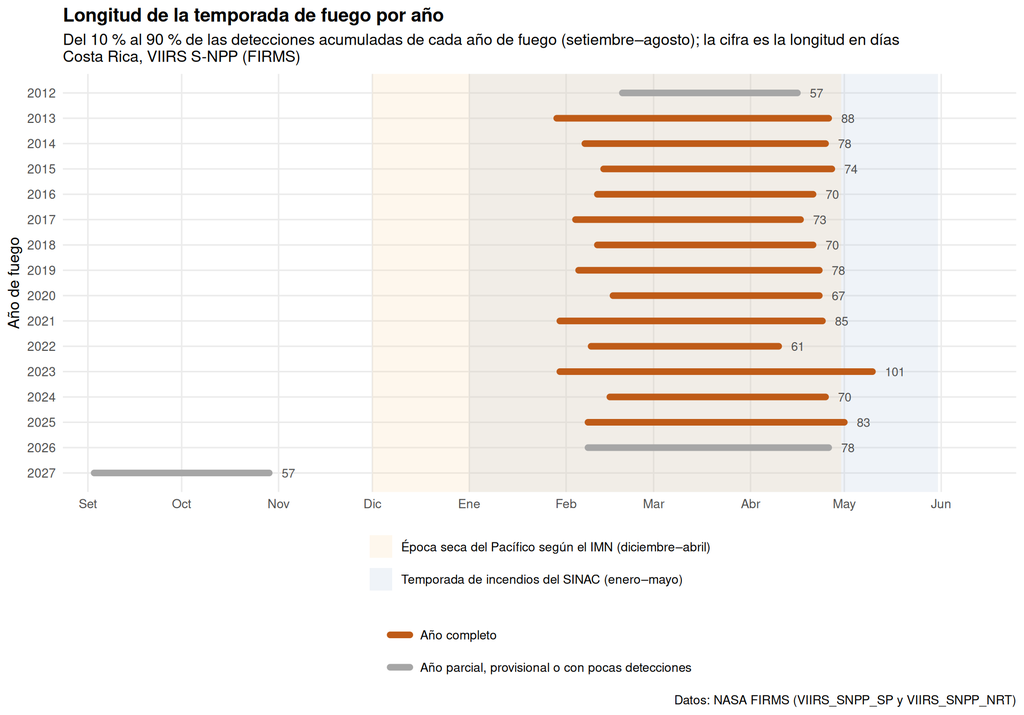

En los **13 años completos** (2013 a 2025, sin reservas de lectura) la temporada dura en promedio **77 días**, entre los 61 de 2022 y los 101 de 2023. La mediana del inicio cae el 8 de febrero y la del fin el 24 de abril. El inicio más temprano fue el 29 de enero de 2013 y el más tardío el 16 de febrero de 2020; el fin más temprano, el 10 de abril de 2022, y el más tardío, el 10 de mayo de 2023.

Los años en gris tienen alguna reserva: el año de fuego 2012 es **parcial** (el procesamiento estándar de Suomi-NPP empieza el 20 de enero de 2012 y le faltan setiembre a diciembre de 2011 y las tres primeras semanas de enero), igual que el año de fuego recién iniciado; un año es **provisional** cuando parte de sus días proviene del procesamiento en tiempo casi real (hoy, los meses posteriores a 31 de julio de 2026).

| Año de fuego | Detecciones | Inicio (10 %) | Fin (90 %) | Longitud (días) | Días de fuego | N50 (días) | C10 (%) | FRP mediana (MW) | FRP p95 (MW) | Días extremos | % en días extremos | Nota |
| --- | --- | --- | --- | --- | --- | --- | --- | --- | --- | --- | --- | --- |
| 2012 | 5350 | 19 de febrero | 15 de abril | 57 | 142 | 19 | 31.9 | 4.5 | 18.6 | 14 | 40.6 | año parcial |
| 2013 | 8562 | 29 de enero | 26 de abril | 88 | 221 | 31 | 23.7 | 4.3 | 19 | 17 | 34.3 |  |
| 2014 | 6526 | 7 de febrero | 25 de abril | 78 | 248 | 27 | 24.9 | 4.6 | 21.2 | 10 | 24.9 |  |
| 2015 | 6664 | 13 de febrero | 27 de abril | 74 | 246 | 26 | 26 | 4.4 | 19.4 | 16 | 36.9 |  |
| 2016 | 8077 | 11 de febrero | 20 de abril | 70 | 237 | 25 | 28.2 | 4.7 | 20.7 | 21 | 45.5 |  |
| 2017 | 4427 | 4 de febrero | 17 de abril | 73 | 201 | 25 | 24.7 | 4.6 | 21.5 | 5 | 13.8 |  |
| 2018 | 5772 | 11 de febrero | 21 de abril | 70 | 210 | 24 | 27.1 | 4.5 | 19.1 | 12 | 31.1 |  |
| 2019 | 7229 | 5 de febrero | 23 de abril | 78 | 232 | 26 | 25.3 | 4.3 | 17.5 | 18 | 39.4 |  |
| 2020 | 6058 | 16 de febrero | 22 de abril | 67 | 213 | 26 | 23.4 | 4.5 | 17.9 | 14 | 31.3 |  |
| 2021 | 2445 | 30 de enero | 24 de abril | 85 | 206 | 23 | 31.2 | 4.6 | 20.2 | 1 | 4.5 |  |

[output cut: 6 more lines]

La tabla completa, con las fechas y las marcas por año, está disponible como CSV.

### Concentración diaria del fuego

`N50` es el número mínimo de días del año de fuego que, ordenados de mayor a menor, reúnen la mitad de las detecciones, y `C10` el porcentaje del total que ocurre en los 10 días más activos. Como `LON`, se definen por fracciones del total anual y son comparables entre plataformas.

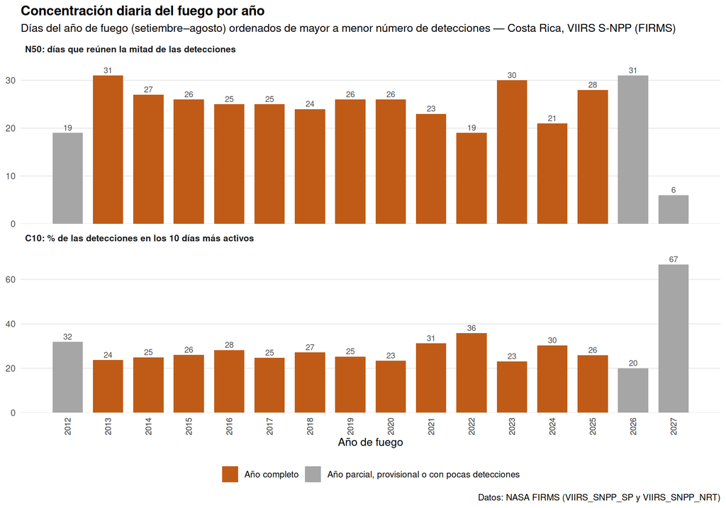

En los años completos, la mitad del fuego del año cabe en promedio en **25 días**, entre los 19 de 2022 y los 31 de 2013, sobre unos 219 días de fuego por año. Los 10 días más activos concentran en promedio el **27 %** de las detecciones, desde el 23 % de 2023 hasta el 36 % de 2022.

### Intensidad del fuego

`FRPI` es la mediana de la **potencia radiativa del fuego** (FRP, en megavatios) de las detecciones de vegetación del año de fuego y `FRP95` su percentil 95. En VIIRS la FRP es por píxel de 375 m, un mismo fuego se reparte en varios píxeles y el algoritmo la deriva de la banda M13, así que **sus valores no se comparan con los de MODIS**, que rondan los 15 MW de mediana: solo se comparan entre años de esta misma serie. Suomi-NPP es un solo satélite, de modo que no existe aquí el control de mezcla de satélites (`AQ`) de la serie MODIS; sí se conserva la fracción nocturna (`noc`), mayor que en MODIS porque el píxel de 375 m detecta de noche fuegos pequeños.

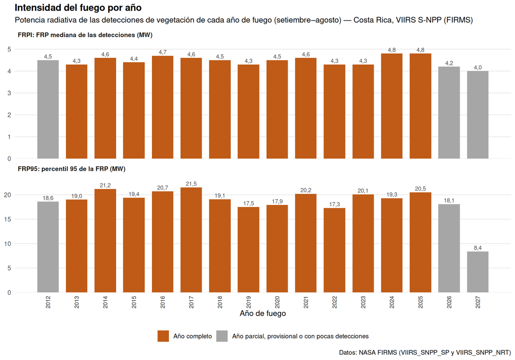

En los años completos la FRP mediana es de **4,5 MW**, entre los 4,3 de 2013 y los 4,8 de 2024; el percentil 95 promedia 20 MW y alcanzó 22 MW en 2017. El 25 % de las detecciones son nocturnas.

### Días extremos

Cuánto del fuego del año ocurre en días que, por su número de detecciones, son extremos respecto del registro: el umbral `P95` es el percentil 95 de las detecciones diarias en los días con fuego del **periodo base 2013–2025**, que en esta plataforma coincide con los años completos del registro (un solo satélite en órbita mantenida, sin los cambios de instrumental que acortan el de MODIS). El umbral es propio de la serie y no se compara con el de MODIS.

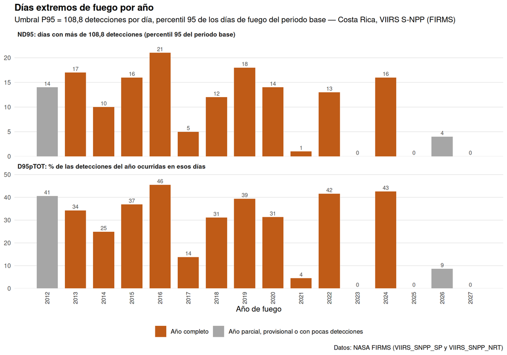

El umbral es de **108,8 detecciones por día**. En los 13 años completos hubo en promedio 11,0 días extremos por año, con un máximo de 21 en 2016; esos días concentran en promedio el 27 % de las detecciones del año, y hasta el 46 % en 2016. Hubo 2 años sin ningún día extremo (2023, 2025).

### Temporada consolidada por celda

Para cada celda de 0,1° (~11 km) de la grilla común a las plataformas se juntan las detecciones de vegetación de los años de fuego completos (2013–2025) y se calculan `INI`, `FIN` y `LON` sobre esa distribución de fechas: la temporada climatológica de la celda. Las celdas con menos de 30 detecciones acumuladas quedan sin índices y se dibujan en gris, y las que tienen más del 25 % de sus detecciones fuera de diciembre a mayo (`FUERA`) se marcan **sin estación definida** y van con trama. Los umbrales son los mismos que en MODIS; como VIIRS acumula muchas más detecciones, los cumplen más celdas, lo que da un mapa más completo pero no más preciso donde ambas plataformas lo tienen.

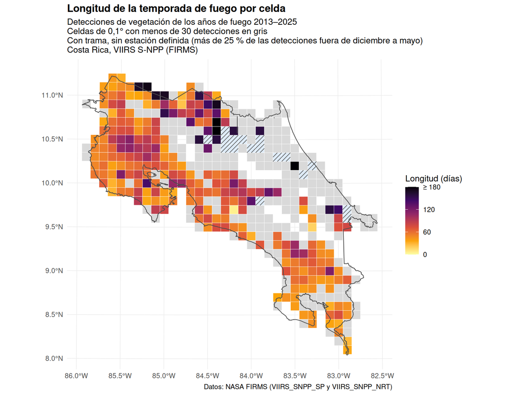

De las 523 celdas con alguna detección, 269 alcanzan el umbral y 17 de ellas quedan sin estación definida, con entre 25 y 59 % de sus detecciones fuera de diciembre a mayo (en las demás la mediana es 1 %). En las 252 celdas con índices la temporada consolidada dura entre 6 y 202 días (mediana 62). El inicio más temprano de celda cae el 5 de octubre y el más tardío el 8 de abril; el fin, entre el 17 de marzo y el 5 de agosto. En el mapa de longitud la escala de color se acota en 180 días.

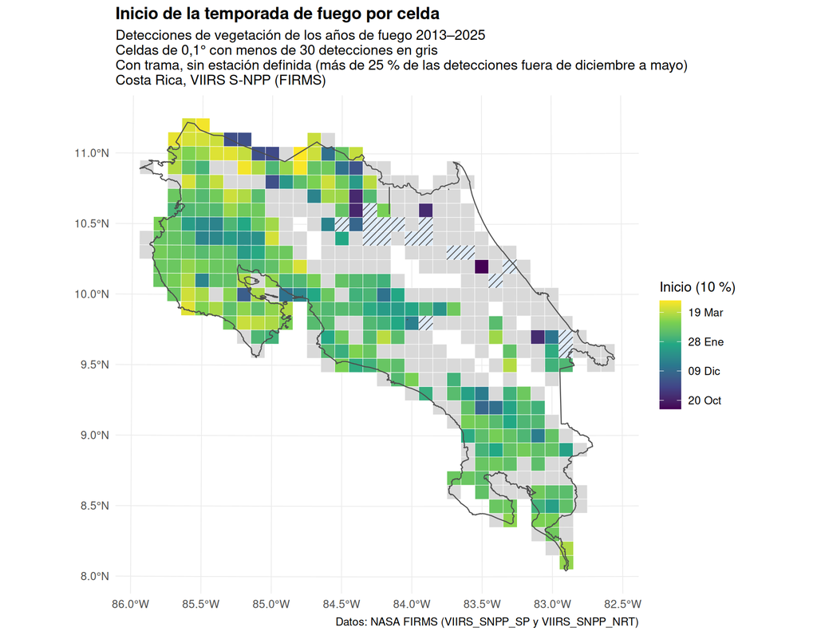

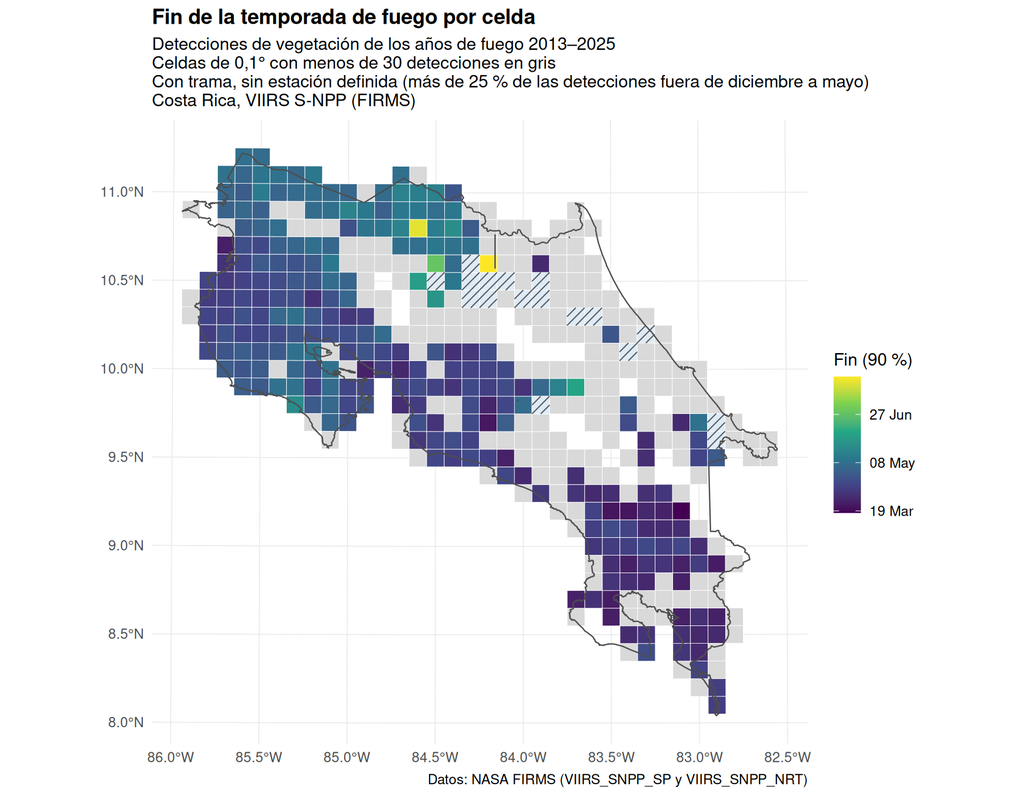

`N50F` es la versión por celda de la concentración: la proporción de los días de fuego de la celda que reúnen la mitad de sus detecciones (0,5 repartido; hacia 0, en oleadas), con un umbral de 100 detecciones que cumplen 143 celdas, con valores entre 0,10 y 0,46 (mediana 0,20).

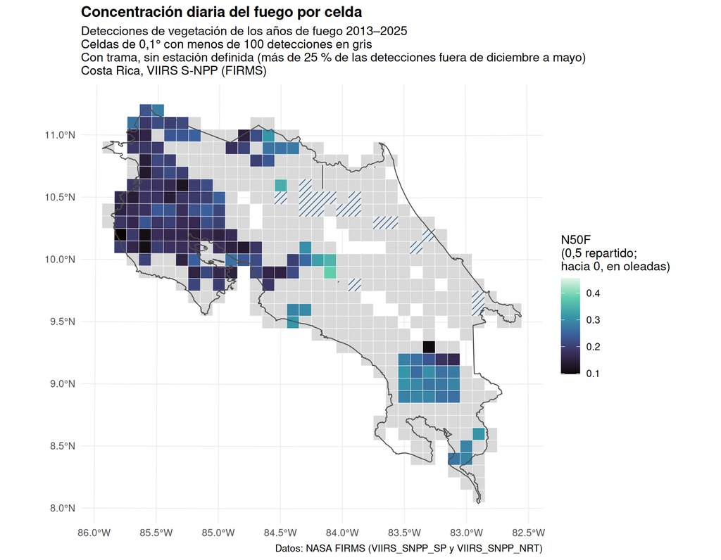

### Frecuencia y densidad por celda

Para cada celda de la grilla, incluidas las que nunca tuvieron fuego, `FREC` es la fracción de años con al menos una detección y `DENS` las detecciones por km² de superficie terrestre y por año, ambas sobre el **periodo base 2013–2025**. Las celdas con menos de 10 km² de tierra quedan en gris. Las densidades son propias de VIIRS y no se comparan con las de MODIS, que ve unas cinco veces menos detecciones; `FREC` tampoco es comparable del todo, porque una celda con fuegos pequeños «arde más años» para el píxel de 375 m.

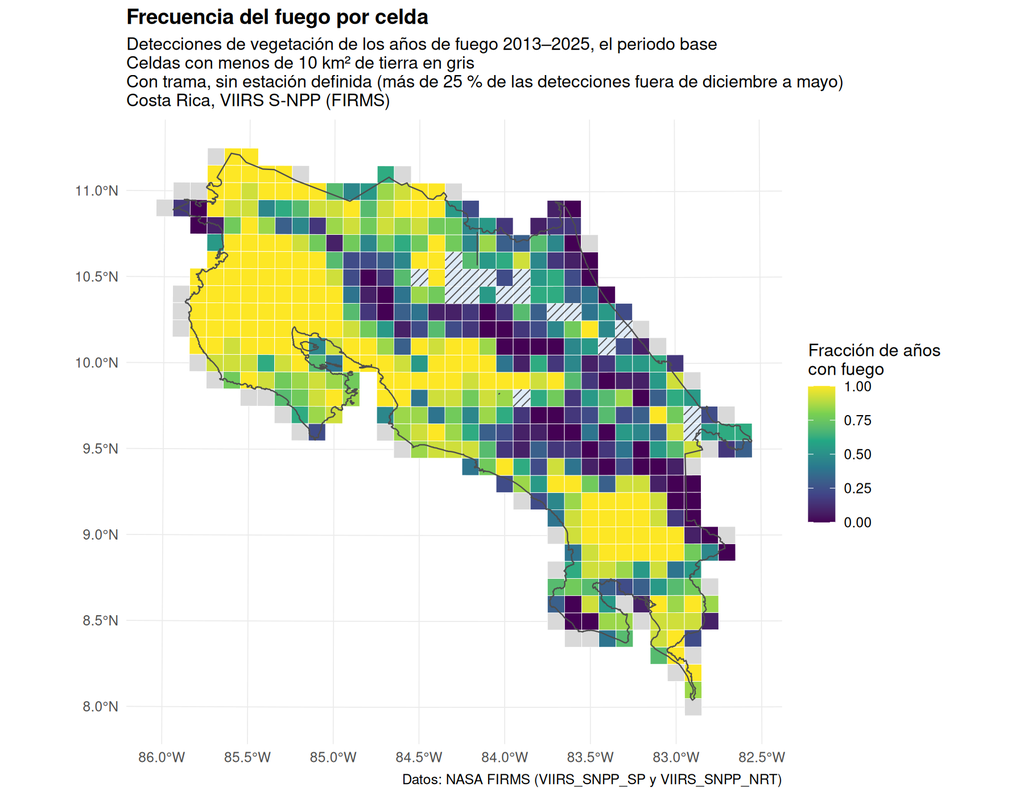

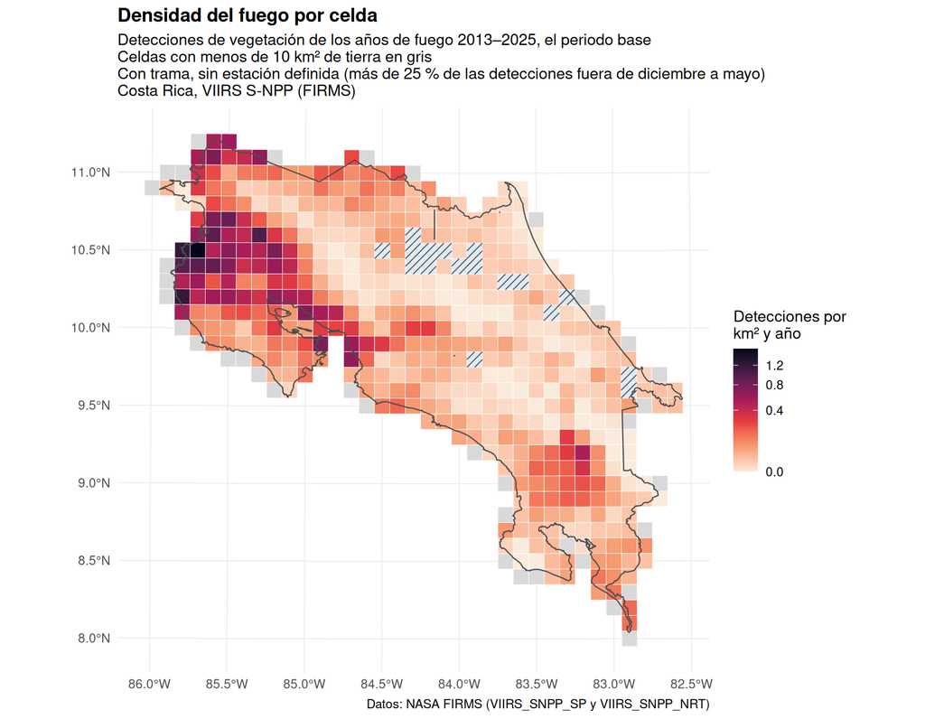

De las 523 celdas que tocan el país, 39 no tuvieron ninguna detección de vegetación en el periodo base; 255 celdas arden tres de cada cuatro años o más y 70 lo hacen menos de uno de cada cuatro. La densidad mediana entre las celdas con fuego es de 0,038 detecciones por km² y año, con un máximo de 1,60.

### Intensidad por celda

Sobre las detecciones del periodo base, cada celda con al menos 30 detecciones lleva su FRP mediana (`FRPI`). No hay mapa de ciclo diurno (`AQ`): ese control mide la mezcla de dos satélites en una misma serie y aquí hay uno solo.

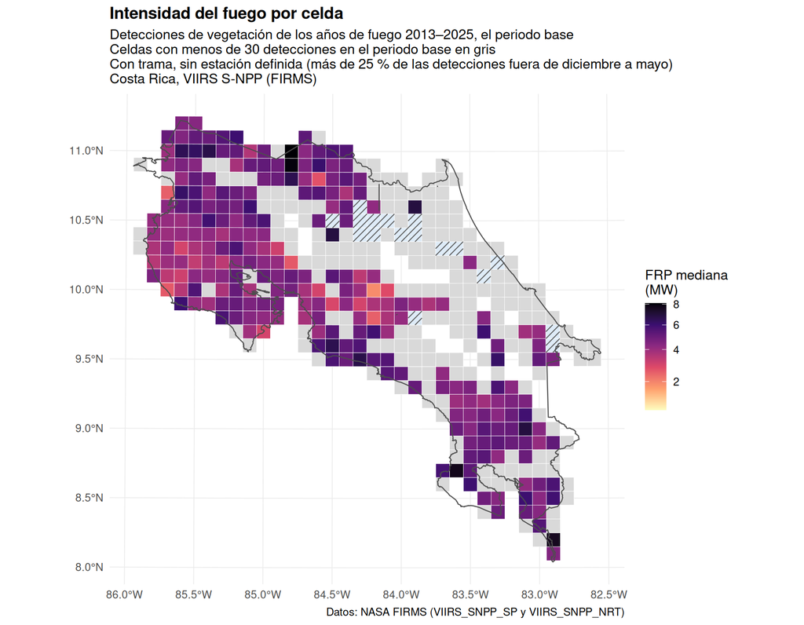

En las 269 celdas que alcanzan el umbral, la FRP mediana va de 0,8 a 8,1 MW (mediana entre celdas, 4,7).

Los índices por celda están disponibles como CSV y como GeoTIFF con las mismas diez bandas con nombre que el de MODIS (`ini_dia`, `fin_dia`, `lon`, `fuera`, `n50f`, `dtot`, `frec`, `dens`, `frpi` y `aq`; esta última vacía en VIIRS), la plataforma y los periodos en los metadatos, y un estilo `.qml` de QGIS con la simbología de `LON`. Las mismas celdas pueden activarse como capa del mapa interactivo.

### Temporada por área de conservación

Los mapas por celda no tienen versión anual porque una celda reúne pocas detecciones en un año; el **área de conservación** (AC) del SINAC sí las reúne, y es la unidad con la que se gestiona el fuego. Cada detección de vegetación se asigna al AC que la contiene y los índices de la suite se calculan por AC y año de fuego con las mismas definiciones que la tabla nacional: `INI`, `FIN`, `LON`, `N50` y `C10` cuando el AC suma al menos 100 detecciones en el año (el 10 % de cien son diez detecciones; con menos la fecha saltaría con un día de quemas), la FRP mediana con 30, y los días extremos contra el percentil 95 de los propios días de fuego del AC en el periodo base. Con el píxel de 375 m de VIIRS, tres de cada cuatro pares AC-año alcanzan el umbral, y el periodo base (2013–2025) coincide con los años completos.

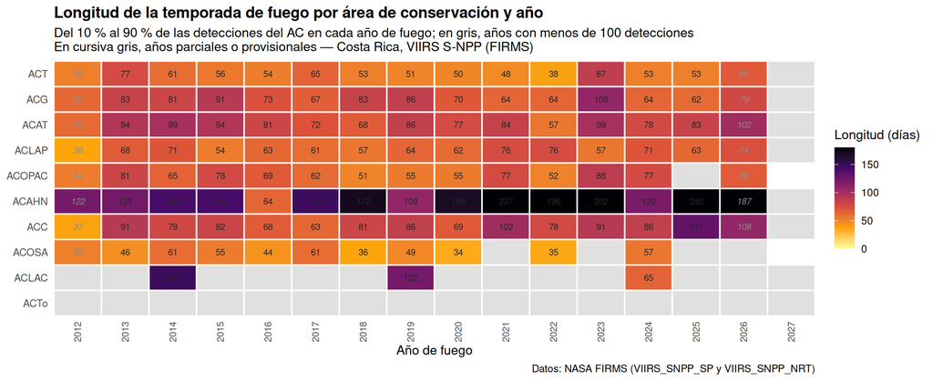

De los 130 pares AC-año completos, 103 (79 %) alcanzan el umbral y tienen temporada fechada. Nunca lo alcanzan ACTo: con esta plataforma no reúnen cien detecciones de vegetación en ningún año. La temporada más larga en promedio es la de **ACAHN** (162 días) y la más corta la de ACOSA (48). La lectura por filas dice si un año largo lo fue en todo el país o solo en una región; la lectura por columnas, qué AC arrastran la temporada nacional.

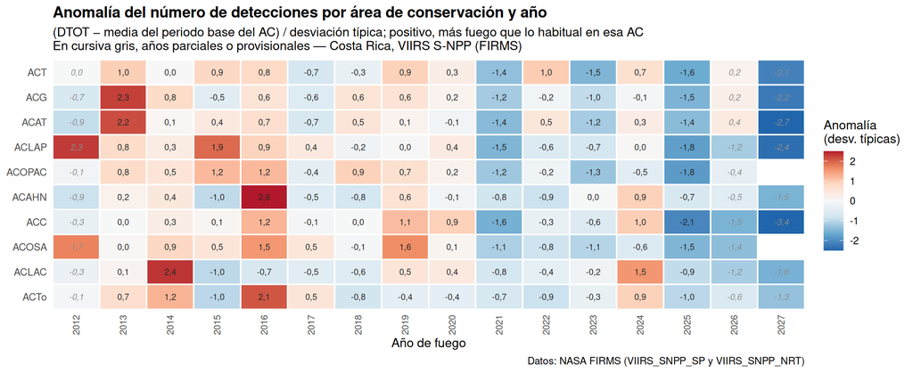

La anomalía estandarizada del número de detecciones (`Z_DTOT`, respecto de la media y la desviación típica de cada AC en el periodo base) es comparable entre AC porque es adimensional. El año con más AC por encima de una desviación típica fue **2016** (5 AC) y el año con más AC por debajo, 2025 (8).

| AC | Nombre | km² de tierra | Detecciones | Inicio (10 %) | Fin (90 %) | Longitud (días) | Fuera de dic–may (%) | N50F | Det./km²/año (base) | FRP mediana (MW) | Nota |
| --- | --- | --- | --- | --- | --- | --- | --- | --- | --- | --- | --- |
| ACT | Tempisque | 5149 | 22693 | 16 de febrero | 17 de abril | 61 | 1 | 0,10 | 0,339 | 4,0 |  |
| ACG | Guanacaste | 2936 | 13218 | 12 de febrero | 1 de mayo | 79 | 2 | 0,14 | 0,346 | 5,1 |  |
| ACAT | Arenal Tempisque | 3690 | 12559 | 1 de febrero | 25 de abril | 84 | 2 | 0,15 | 0,262 | 4,6 |  |
| ACLAP | La Amistad Pacifico | 5558 | 6159 | 2 de febrero | 7 de abril | 65 | 2 | 0,16 | 0,085 | 4,8 |  |
| ACOPAC | Pacifico Central | 2771 | 5905 | 8 de febrero | 15 de abril | 67 | 1 | 0,14 | 0,164 | 4,6 |  |
| ACAHN | Huetar Norte | 8924 | 4814 | 27 de diciembre | 15 de mayo | 140 | 14 | 0,13 | 0,042 | 5,0 |  |
| ACC | Central | 8609 | 3675 | 27 de enero | 18 de abril | 82 | 4 | 0,17 | 0,033 | 3,7 |  |
| ACOSA | Osa | 4287 | 2599 | 13 de febrero | 4 de abril | 51 | 0 | 0,18 | 0,047 | 5,1 |  |
| ACLAC | La Amistad Caribe | 6068 | 1018 | 4 de noviembre | 5 de mayo | 183 | 19 | 0,20 | 0,013 | 4,3 |  |
| ACTo | Tortuguero | 3049 | 287 |  |  |  | 26 | 0,29 | 0,007 | 4,0 | sin estación definida |

El consolidado por AC se calcula con las mismas funciones y umbrales que el ráster por celda, tomando cada AC como una celda con su superficie terrestre. La temporada climatológica más larga es la de **ACLAC** (183 días) y la más corta la de ACOSA (51); el inicio más temprano cae en ACLAC (4 de noviembre) y el más tardío en ACT (16 de febrero). ACTo queda sin estación definida: más del 25 % de sus detecciones cae fuera de diciembre a mayo, el patrón bimodal del Caribe. La densidad sobre el periodo base va de 0,346 detecciones por km² y año en ACG a 0,007 en ACTo: 48 veces de diferencia entre los extremos del país.

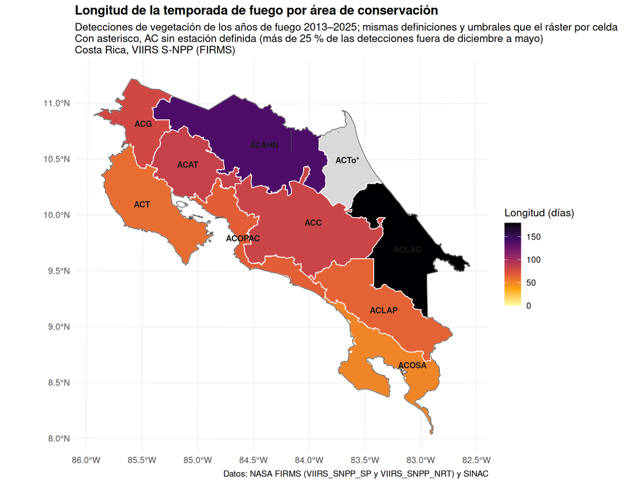

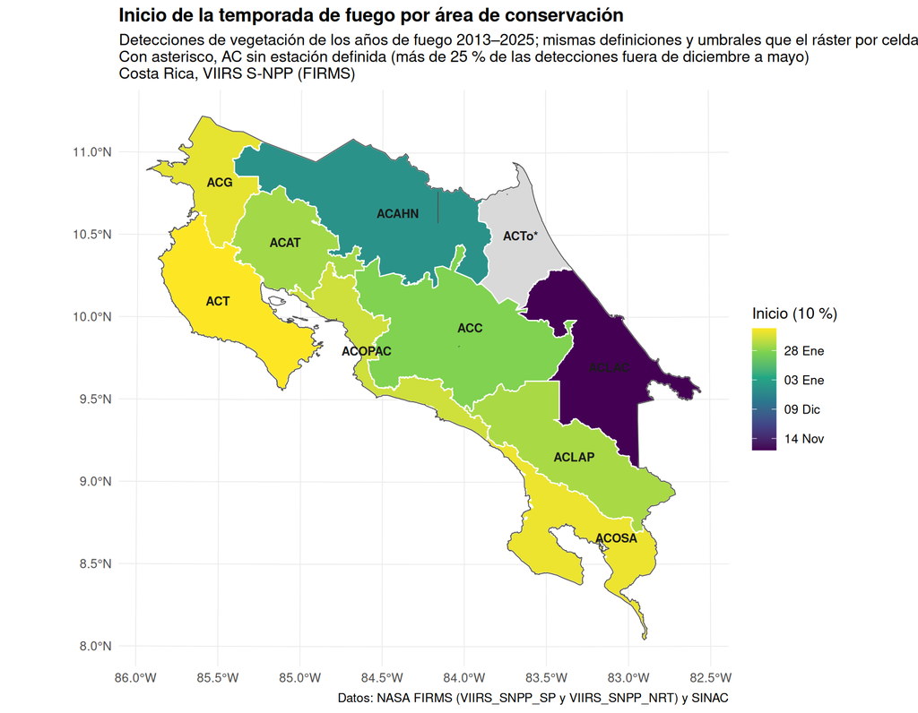

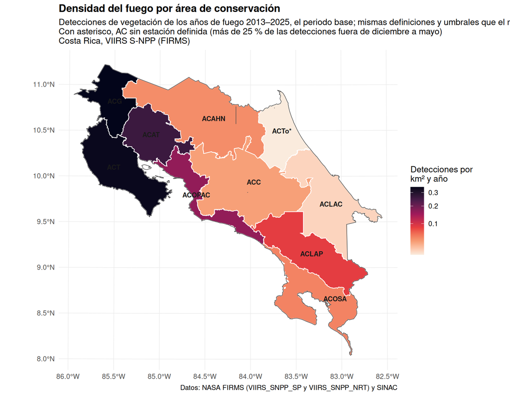

Las tablas están disponibles como CSV: índices anuales por AC y consolidado por AC. Los índices de un AC se comparan entre años y con otras AC de esta misma plataforma; entre plataformas, solo mediante el reporte de comparación.

### Fase ENSO

Es el primer factor externo con que se confrontan los índices anuales. El Niño reduce la lluvia de la vertiente del Pacífico de Centroamérica (Ropelewski y Halpert 1987) y en Costa Rica la variabilidad de la lluvia mensual está ligada al ENSO (Waylen, Caviedes y Quesada 1996); la pregunta es si los años Niño tienen temporadas más largas, más tempranas o con más fuego en el registro de esta plataforma. Se usa el **Índice Oceánico El Niño** (ONI) del CPC de la NOAA en el trimestre **diciembre–febrero** que cae dentro del año de fuego, justo antes de la temporada, ventana fijada antes de mirar los datos, y la fase del CPC (cinco trimestres consecutivos con |ONI| ≥ 0,5 °C). Los índices de conteo entran como anomalías sobre el periodo base para que la detectabilidad no intervenga. Con trece años completos, S-NPP tiene pocos episodios de cada fase; el contraste con MODIS en los mismos años dice si la asociación depende del sensor.

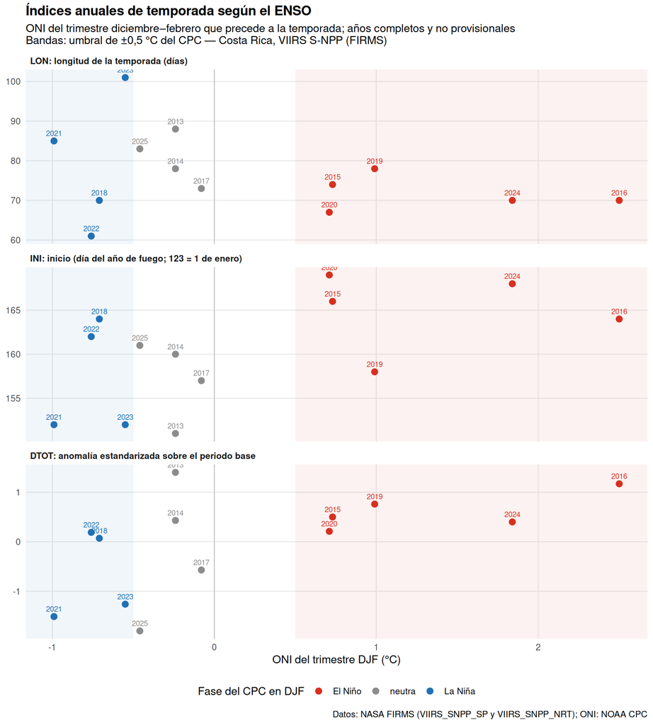

De los 13 años completos, 5 son de El Niño (2015, 2016, 2019, 2020, 2024), 4 de La Niña (2018, 2021, 2022, 2023) y 4 neutros; el ONI de DJF va de 2,5 °C en 2016 a -1,0 °C en 2021. La longitud mediana de la temporada es de 70 días en años Niño, 80 en neutros y 78 en Niña (ρ de Spearman con el ONI -0,26, p = 0,39); el inicio mediano cae el 13 de febrero, el 5 de febrero y el 4 de febrero (ρ 0,45, p = 0,12), y la anomalía del número de detecciones es de 0,5, -0,1 y -0,6 desviaciones típicas (ρ 0,66, p = 0,01). La asociación más fuerte es con ND95 (ρ 0,71), y 3 índices alcanzan p < 0,05 (DTOT, ND95, D95pTOT). Con estas muestras el resultado es descriptivo: dice cómo se ordenan los años, no predice.

| Índice | El Niño: mediana (años) | Neutra: mediana (años) | La Niña: mediana (años) | ρ de Spearman con ONI_DJF | valor p |
| --- | --- | --- | --- | --- | --- |
| LON (días) | 70,0 (5) | 80,5 (4) | 77,5 (4) | -0,26 | 0,388 |
| INI (día) | 166,0 (5) | 158,5 (4) | 157,0 (4) | 0,45 | 0,121 |
| FIN (día) | 235,0 (5) | 237,5 (4) | 234,5 (4) | -0,01 | 0,975 |
| N50 (días) | 26,0 (5) | 27,5 (4) | 23,5 (4) | 0,07 | 0,829 |
| C10 (%) | 26,0 (5) | 24,8 (4) | 29,1 (4) | -0,13 | 0,680 |
| FRPI (MW) | 4,5 (5) | 4,6 (4) | 4,4 (4) | 0,25 | 0,407 |
| DTOT (anomalía) | 0,5 (5) | -0,1 (4) | -0,6 (4) | 0,66 | 0,014 |
| ND95 (anomalía) | 0,7 (5) | -0,5 (4) | -0,6 (4) | 0,71 | 0,006 |
| D95pTOT (anomalía) | 0,8 (5) | -0,4 (4) | -0,5 (4) | 0,62 | 0,025 |

Las tablas están disponibles como CSV: índices por año con ONI y fase y resumen por fase. La serie ONI es de la [NOAA CPC](https://www.cpc.ncep.noaa.gov/products/analysis_monitoring/ensostuff/ONI_v5.php).

### Detecciones excluidas por tipo de fuente

FIRMS clasifica cada detección del procesamiento estándar por tipo de fuente: vegetación, volcán activo, otra fuente estática en tierra o mar. En el registro de Suomi-NPP hay **906** detecciones de los tres últimos tipos, que las series mensuales y los mapas de este reporte sí incluyen pero los índices de temporada apartan. La cola en tiempo casi real no trae el campo, de modo que sus detecciones (*sin tipo*) cuentan como vegetación.

| Año de fuego | Vegetación | Sin tipo (NRT) | Volcán activo | Otra fuente estática | Mar | Excluidas |
| --- | --- | --- | --- | --- | --- | --- |
| 2012 | 5350 | 0 | 90 | 0 | 8 | 98 |
| 2013 | 8562 | 0 | 126 | 0 | 9 | 135 |
| 2014 | 6526 | 0 | 102 | 0 | 7 | 109 |
| 2015 | 6664 | 0 | 42 | 0 | 4 | 46 |
| 2016 | 8077 | 0 | 27 | 11 | 5 | 43 |
| 2017 | 4427 | 0 | 63 | 16 | 9 | 88 |
| 2018 | 5772 | 0 | 54 | 24 | 9 | 87 |
| 2019 | 7229 | 0 | 27 | 19 | 7 | 53 |
| 2020 | 6058 | 0 | 7 | 34 | 8 | 49 |
| 2021 | 2445 | 0 | 2 | 13 | 3 | 18 |

[output cut: 6 more lines]

Disponible también como CSV.

**Dónde están.** Las 811 detecciones de tipo 1 y 2 del registro se reparten en 5 celdas de 0,1°, pero 5 celdas con al menos 10 reúnen el 100 %. A cada celda fuente se le asigna una **firma** por reglas sobre sus propias detecciones (definidas en el [README](https://github.com/incendios-forestales/anomalias-termicas-costarica#mapa-de-fuentes-estáticas)): cráter volcánico si domina el tipo 1; fuente térmica nocturna persistente si al menos la mitad son nocturnas en tres o más años, porque lo que emite de noche está caliente por sí mismo; y reflejo urbano diurno, probable, si casi todas son diurnas, la firma del caso de Turrialba, puntos fijos sobre los techos del casco urbano que la máscara de la NASA catalogó como fuente estática. La localidad es la geocodificación inversa del centroide y dice dónde buscar la fuente, no cuál es.

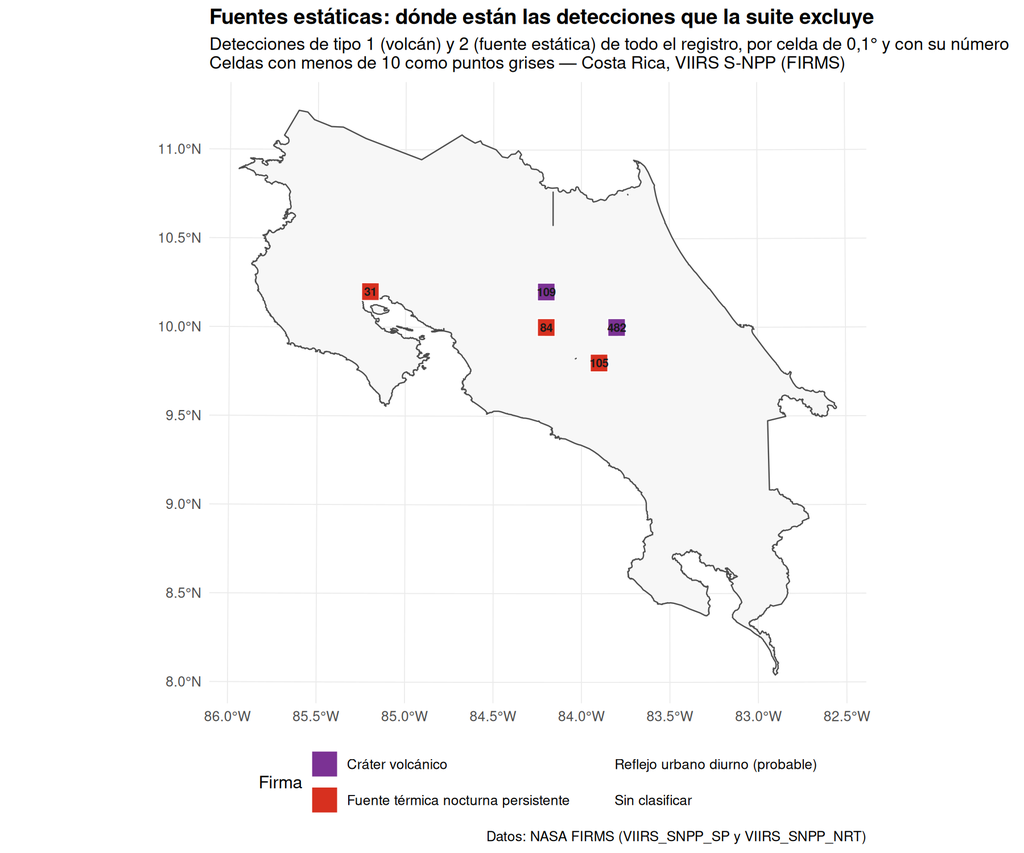

La mayor es Santa Cruz de Turrialba (cráter del Turrialba) (482 detecciones, cráter volcánico). VIIRS ve un mapa distinto del de MODIS: casi no registra los cascos urbanos diurnos y sí unos pocos puntos calientes nocturnos. Cráteres: Santa Cruz de Turrialba (cráter del Turrialba); San Juan de Poás (cráter del Poás). Fuentes térmicas nocturnas persistentes (0 % diurnas en mediana): Aguacaliente de Cartago y Llanos de Santa Lucía, Paraíso; La Ribera y La Uruca, entre Belén y San José; Colorado de Abangares.

| Celda | Localidad de referencia | Firma | Volcán (tipo 1) | Fija (tipo 2) | % de la celda | Años (primero–último) | % diurnas | % de Terra | FRP mediana (MW) | Confianza mediana | Centroide (lat, lon) | Dispersión (m) |
| --- | --- | --- | --- | --- | --- | --- | --- | --- | --- | --- | --- | --- |
| c0995_m08385 | Santa Cruz de Turrialba (cráter del Turrialba) | Cráter volcánico | 482 | 0 | 96 | 11 (2012–2022) | 5 |  | 1,2 |  | 10,0186, -83,7654 | 226 |
| c1015_m08425 | San Juan de Poás (cráter del Poás) | Cráter volcánico | 109 | 0 | 95 | 11 (2012–2026) | 0 |  | 1,1 |  | 10,1971, -84,2311 | 174 |
| c0975_m08395 | Aguacaliente de Cartago y Llanos de Santa Lucía, Paraíso | Fuente térmica nocturna persistente | 0 | 105 | 44 | 11 (2016–2026) | 0 |  | 0,7 |  | 9,8308, -83,9048 | 144 |
| c0995_m08425 | La Ribera y La Uruca, entre Belén y San José | Fuente térmica nocturna persistente | 0 | 84 | 15 | 8 (2016–2026) | 7 |  | 0,5 |  | 9,9664, -84,1558 | 382 |
| c1015_m08525 | Colorado de Abangares | Fuente térmica nocturna persistente | 0 | 31 | 4 | 3 (2024–2026) | 0 |  | 0,8 |  | 10,1998, -85,1827 | 124 |

Todas las celdas con detecciones estáticas, con sus métricas, están en CSV.

## Detecciones por área de conservación

Cada detección se asigna al **área de conservación** del [SINAC](https://www.sinac.go.cr/) donde cae su punto; cada píxel de área quemada, a la del centroide del píxel. Las pocas detecciones que no caen en ninguna —desajustes de borde entre la capa del SINAC y el límite IGN 1:5000— se agrupan como *Sin asignar*.

[interactive chart not shown]

| Siglas | Área de conservación | Detecciones | % del total | Hectáreas quemadas |
| --- | --- | --- | --- | --- |
| ACT | Tempisque | 26331 | 31.1 | 201050 |
| ACG | Guanacaste | 15081 | 17.8 | 160861 |
| ACAT | Arenal Tempisque | 14340 | 17 | 127143 |
| ACLAP | La Amistad Pacifico | 7331 | 8.7 | 19218 |
| ACOPAC | Pacifico Central | 6726 | 8 | 21272 |
| ACAHN | Huetar Norte | 5270 | 6.2 | 22129 |
| ACC | Central | 4883 | 5.8 | 3549 |
| ACOSA | Osa | 3061 | 3.6 | 4062 |
| ACLAC | La Amistad Caribe | 1105 | 1.3 | 556 |
| ACTo | Tortuguero | 327 | 0.4 | 428 |

[output cut: 1 more lines]

La distribución por año y área de conservación está disponible como CSV.

## Cobertura de la tierra

Cada detección VIIRS corresponde a un píxel de 375 m en el nadir (mayor fuera de él), por lo que la cobertura se caracteriza sobre el *footprint* completo de la detección (una elipse con las dimensiones reales del píxel, columnas `scan` × `track`) y no sobre el punto exacto. El footprint mediano de este registro ronda 0,2 km², frente a más de 1 km² en MODIS: la atribución de cobertura es sustancialmente más precisa, y este es el punto donde más se notará la diferencia entre ambos sensores.

**Limitación**: WorldCover describe la cobertura de 2021, mientras que el registro de detecciones abarca 2012–2026; los cambios de cobertura en ese período no están representados.

Cada barra se divide además según la detección caiga o no dentro de un humedal del [Registro Nacional de Humedales](https://geos1pne.sirefor.go.cr/wfs) del SINAC (actualización 2016–2018 del Inventario Nacional de Humedales). El humedal no es un tipo de vegetación que compita con *pastizal* o *bosque*, sino una condición del sitio: las capas del SINAC inventarían rasgos específicos y no cubren todo el territorio, por lo que no pueden sustituir a WorldCover como clasificación exhaustiva, pero sí complementarla.

[interactive chart not shown]

El gráfico gemelo muestra las **hectáreas quemadas** según la clase dominante del píxel VNP64A1. Aquí la clase se asigna al píxel de 500 m completo —no a un footprint elíptico— y aplica la misma limitación de la foto fija de 2021.

[interactive chart not shown]

### Contraste con el Registro Nacional de Humedales

WorldCover es un producto global y clasifica como *pastizal* buena parte de la vegetación herbácea inundable del país. El contraste con el registro de humedales permite distinguir cuánto del fuego “en pastizal” ocurre en realidad en humedales estacionales.

| Clase WorldCover | Detecciones | En humedal | % en humedal | Fracción del footprint en humedal | Hectáreas quemadas | % del área quemada en humedal |
| --- | --- | --- | --- | --- | --- | --- |
| Bosque | 58140 | 1967 | 3.4 | 0.013 | 285947 | 3.5 |
| Pastizal | 19888 | 2112 | 10.6 | 0.062 | 138089 | 12.2 |
| Cultivos | 4887 | 350 | 7.2 | 0.04 | 136742 | 5.5 |
| Zonas construidas | 729 | 6 | 0.8 | 0.001 | 150 | 0 |
| Suelo desnudo / vegetación escasa | 596 | 98 | 16.4 | 0.065 | 0 |  |
| Humedal herbáceo | 120 | 106 | 88.3 | 0.72 | 385 | 100 |
| Cuerpos de agua | 115 | 56 | 48.7 | 0.278 | 791 | 32.4 |
| Manglar | 103 | 50 | 48.5 | 0.223 | 770 | 58.3 |
| Matorral | 5 | 0 | 0 | 0 | 64 | 0 |

De las **19 888** detecciones cuyo footprint domina el *pastizal* de WorldCover, el **10,6 %** cae dentro de un humedal registrado (con un **6 %** del footprint cubierto por humedal, en promedio). El polígono del registro que más detecciones concentra es *Sector Catalina 1*, con 205. Con footprints cinco veces más pequeños que los de MODIS, este contraste está menos expuesto al desborde geométrico del píxel grueso.

**Advertencia sobre la clase de humedal**: el registro asigna una sola clase por polígono; `clase_hum` describe el tipo de humedal *como sitio* y no la cobertura en cada punto de su extensión. El cruce es concluyente para responder si las detecciones ocurren en humedal, no para determinar qué tipo de vegetación se quemó.

## El episodio del humedal Catalina, mayo de 2026

Casi todo lo que este reporte mide carece de contraparte en tierra: nadie levantó un inventario de las quemas de 2014 para comparar. El episodio de mayo de 2026 en el humedal Catalina (Parque Nacional Palo Verde, cuenca baja del Tempisque) es la excepción, y por eso merece una sección propia. El 28 de mayo de 2026 la caída de un rayo encendió el interior del humedal, y una semana después Delfino.cr reportaba, con cifras del Minae-Sinac, que el fuego había afectado **cerca de 4 000 hectáreas** ([nota del 3 de junio de 2026](https://delfino.cr/2026/06/incendio-en-parque-nacional-palo-verde-afecto-cerca-de-4000-hectareas)). El combustible principal fue la *Typha*, una planta invasora que arde incluso sobre el agua. Tenemos entonces una fecha de ignición, una causa y una superficie oficial: tres cosas con las que auditar los productos satelitales.

**Lo que vio esta plataforma.** VIIRS en Suomi-NPP registró **102 detecciones** en la ventana del evento repartidas en 3 días, del 29 de mayo al 31 de mayo de 2026 —es decir, el fuego apareció en las imágenes 1 día después de la ignición reportada—, con una potencia radiativa acumulada de 960 MW y un máximo de 55,9 MW en un solo píxel. 29 de esas detecciones son nocturnas: el fuego no se apagaba de noche.

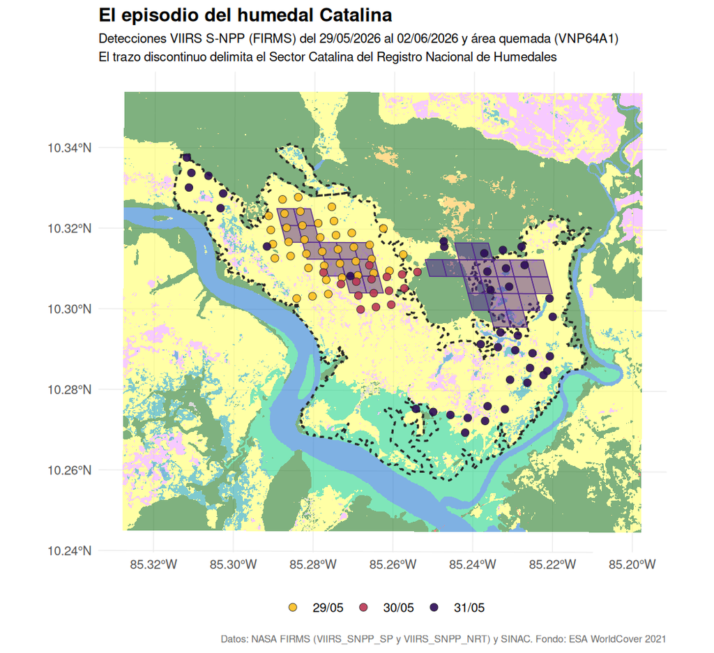

**Dónde ardió.** El **90,2 %** de las detecciones del episodio tiene como polígono dominante el *Sector Catalina* del Registro Nacional de Humedales, y el **93,1 %** cae en footprints donde WorldCover ve *pastizal*. Es un ejemplo concreto del hallazgo de la sección anterior: parte del “pastizal” que arde en Costa Rica no es potrero sino humedal estacional, y en este caso sabemos por la fuente periodística que lo que ardió fue un typhal sobre agua.

**Lo que el área quemada no vio.** Aquí está el resultado que más obliga a matizar el resto del reporte. Para mayo y junio de 2026, VNP64A1 marca **3228 hectáreas** quemadas en la zona del evento, frente a las 4 000 reportadas oficialmente: el producto satelital ve **1,2 veces menos superficie** que la contabilizada en tierra. El mapa de arriba lo muestra sin necesidad de cifras: las detecciones de fuego activo cubren buena parte del sector, mientras que los píxeles de área quemada forman unas pocas manchas sueltas.

La explicación está en cómo funciona el producto. VNP64A1 declara quemado un píxel de 500 m cuando detecta un **cambio persistente de reflectancia**, y una quema de *Typha* sobre lámina de agua no lo produce: la vegetación emergente desaparece, el agua vuelve a dominar la señal y a las pocas semanas la superficie se parece a lo que era antes. A eso se suma que el píxel de 500 m no resuelve las cicatrices delgadas e interrumpidas que deja un fuego que avanza entre canales. No es un defecto de este episodio: es el comportamiento esperable del algoritmo en humedales, y advierte contra leer las hectáreas de la tabla anual como una medida de la superficie realmente afectada. **Sirven para comparar años entre sí; no para responder cuántas hectáreas se quemaron.**

**Nivel de procesamiento**: las detecciones del episodio provienen del procesamiento en estándar. Los datos en tiempo casi real se refinan cuando la NASA los reprocesa a estándar, de modo que los conteos de esta sección pueden cambiar retroactivamente.

## Fuentes de datos

- **NASA FIRMS** — Fire Information for Resource Management System, producto VIIRS_SNPP_SP (VIIRS 375 m, Suomi-NPP, procesamiento estándar). https://firms.modaps.eosdis.nasa.gov/. Cita sugerida: Schroeder, W., y Giglio, L. (2018). *VIIRS/NPP Thermal Anomalies/Fire 6-Min L2 Swath 375m*, DOI: 10.5067/VIIRS/VNP14IMG.002.
- **NASA LP DAAC** — producto de área quemada VNP64A1 v002 (VIIRS/NPP, mensual, 500 m), descubierto vía el API CMR de Earthdata. Giglio, L., y Justice, C. (2021). *VNP64A1 VIIRS/NPP Burned Area Monthly L4 Global 500m SIN Grid V002*, DOI: 10.5067/VIIRS/VNP64A1.002.
- **IGN / SNIT** — Instituto Geográfico Nacional, cartografía oficial 1:5000: límite provincial (la unión de las siete provincias es el límite nacional del análisis). https://www.snitcr.go.cr/.
- **SINAC** — Sistema Nacional de Áreas de Conservación de Costa Rica. Capas de áreas de conservación y Registro Nacional de Humedales (actualización 2016–2018), descargadas de su servicio WFS. https://geos1pne.sirefor.go.cr/wfs.
- **ESA WorldCover** — mapa global de cobertura de la tierra 2021 a 10 m, v200. https://esa-worldcover.org/. Zanaga, D., et al. (2022). *ESA WorldCover 10 m 2021 v200*, DOI: 10.5281/zenodo.7254221.

Los reportes análogos: MODIS (desde 2001), VIIRS en NOAA-20 (desde 2018) y VIIRS en NOAA-21 (desde 2024).

El código de este análisis está disponible en https://github.com/incendios-forestales/anomalias-termicas-costarica.